# Ambulance Optimization through Response Clustering

Conor D’Arcy, Alexander Chan

11/18/2016

The problem that we chose to attempt to solve was that of ambulance placement. Traditionally, ambulances are not given locations to drive to when they finish a call; drivers are allowed to choose a docking location until their next call. Ideally, ambulances would dock at a location that would likely reduce the response time of the next call. However, in practice, most locations are chosen by parameters that benefit the driver instead of the patient (i.e. proximity to a favorite restaurant).

Current research on transportation optimization lies heavily in the routing of the vehicle, but almost always makes the basic assumption of a random starting point (Except in cases where the starting point is a depot, which we believe to still be sub-optimal). By optimizing the starting location of a vehicle, we could use our methods in conjunction with current dynamic routing models to achieve the most efficient solution.

To find the optimal docking locations of ambulances, we had to make some underlying assumptions.

- First, ambulance call origins occur in a non random way. We believe that origins of calls will have higher probabilities in some locations than in others. For example, locations with high density of bars tend to see more ambulances than those with high density of churches.
- Second, Euclidean distance is a good metric for comparison between models. When comparing our model to the current model, we believe Euclidean distance is a good approximation to response time. While actual travel time or distance may be considerably larger, since both models use the same distance, the results of the euclidean comparison should be similar to those of actual distance (Something that reduces euclidean distance should, on average, reduce travel distance).

Our solution gravitated to k-means for two main reasons.

- First, we knew we wanted to cluster our data. Given our assumption of non-random call origins is true, natural pockets of call origins should establish themselves. The plot below illustrates this concept - places of higher population density, such as Downtown Seattle, have more centroids than the outskirts of Seattle. We believe that average response times in these pockets can be reduced by docking ambulances in their centers.
- The second reason for choosing k-means is that we know the number of clusters we want before we cluster our data. We know that we need as many clusters as the number of ambulances currently on call.

[interactive chart not shown]

The Paramedic services of the Seattle Region is run by the [Seattle & King County Emergency Medical Services System](https://en.wikipedia.org/wiki/Seattle_%26_King_County_Emergency_Medical_Services_System), which runs a fleet 41 ambulances.

The current method for ambulance allocation is as follows: Let $\alpha$ and $\beta$ be two matrix representations of disjoint sets of ambulances where $\alpha$ is a matrix of all longitude/latitude coordinates of ambulances who are available to respond to a call while $\beta$ is a matrix representation of all other ambulances.  
When a call is received, the controller finds the minimum distance from the call location and the individual locations of ambulances within $\alpha$.

Let $\phi=(\phi_{1},\phi_{2})$ where $\phi$ represents longitude and latitude of the pickup location.

The controller now assigns $\alpha_{i}$ to the call and removes them from $\alpha$ and appends them to $\beta$. Any time a call is received, $\alpha$ and $\beta$ are updated with the current locations of ambulances. Any time a patient is delivered, that ambulance is removed from $\beta$ and appended to $\alpha$.

Our method of optimization concentrates on improving $\alpha$. We propose that the optimal solution to this problem follows:

Assume $\beta=\emptyset$. Cluster all previous phone calls into n unique clusters, denoted by $\chi$ where n is the number of rows in $\alpha$. Let $\Delta=\sqrt{(1)'((\chi - \alpha)(1,1)')^2}$, with the order of rows of $\chi$ and $\alpha$ being matched by location. We believe the lower the value of $\Delta$, the lower the average response time will be.

Initially, to examine the validity of our hypothesis we hoped to calculate the correlation coefficient between $\Delta$ and average response time. However, we soon realized that finding a unique pairing of rows in $\alpha$ with rows in $\chi$ was non polynomial in time, and a research topic in itself. Thus, we needed a new method of evaluating our hypothesis.

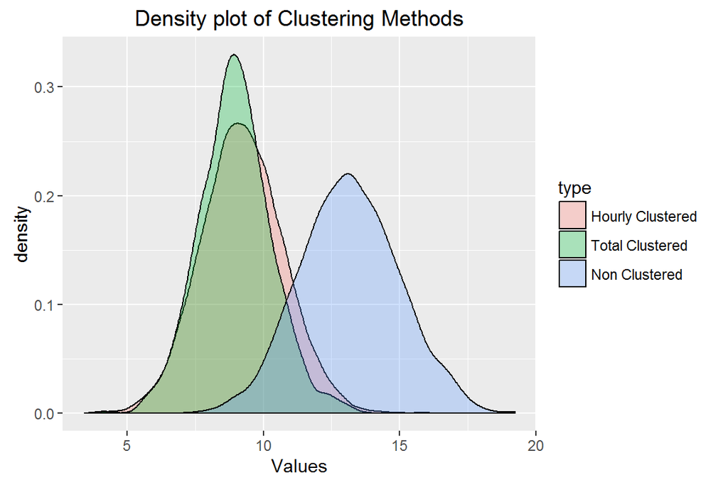

| Model | Median distance | Mean distance | Min distance | Max distance | Reduction % | P value |
| --- | --- | --- | --- | --- | --- | --- |
| Status Quo | 13.1509759 | 13.1686502 | 7.8125178 | 19.2281745 | NA | NA |
| Total Clustering | 8.9520282 | 8.9743735 | 4.1271313 | 13.3950404 | 0.3060262 | 0 |
| Hourly Clustering | 9.2087194 | 9.2319669 | 3.4301714 | 16.2182633 | 0.2895585 | 0 |

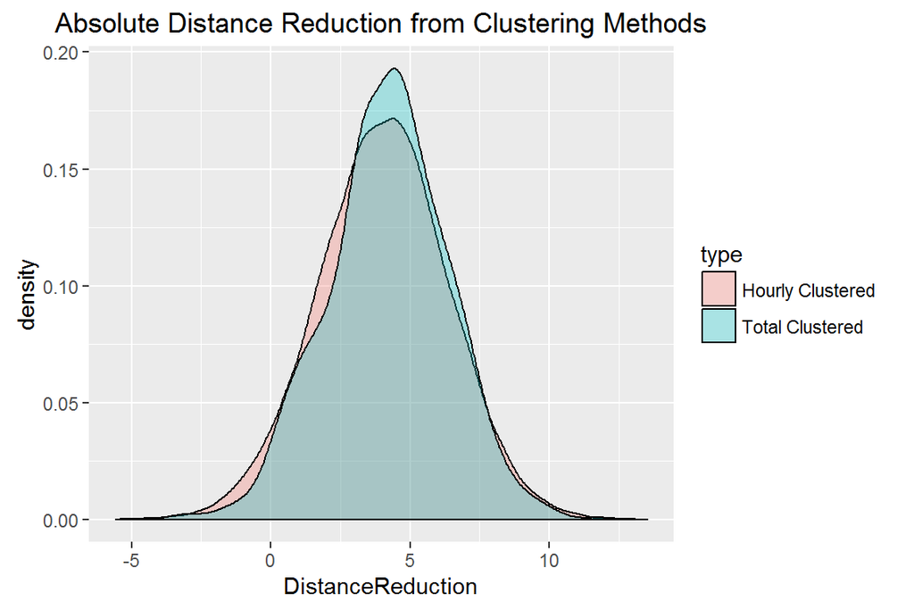

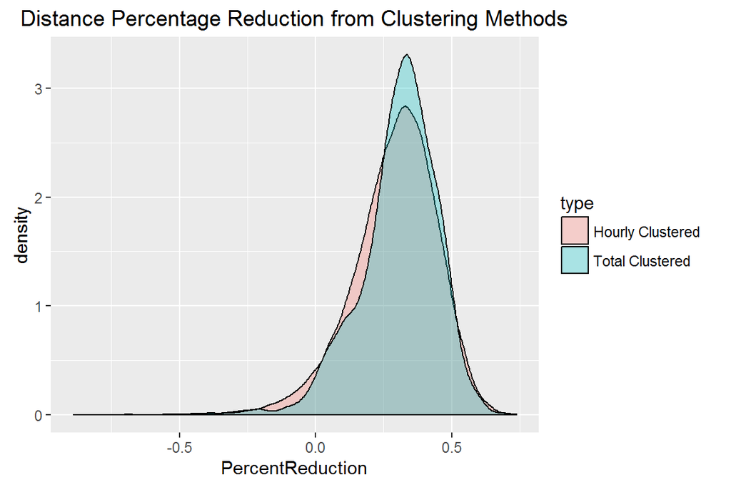

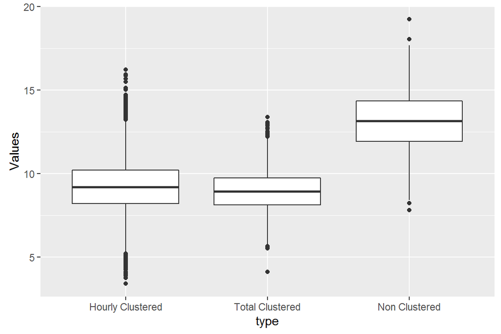

#### Total Clustering Model

[interactive chart not shown]

#### Hourly Clustering Model at Midnight

[interactive chart not shown]

#### Hourly Clustering Model at 9AM

[interactive chart not shown]

#### Hourly Clustering Model at Noon

[interactive chart not shown]

#### Hourly Clustering Model at 6 PM

[interactive chart not shown]

## Appendix

### Simulation Code

```r
#Define our testing function
getTime<-function(numberOfIterations,numOfAmbulances,type="clustered",seed=0,hour=-1)
{
  #Set boundaries for our data
  minLong<-122.2
  maxLong<-122.4
  minLat<-47.46
  maxLat<-47.77
  numberOfAmbulances=numOfAmbulances
  totalTimeTaken<-0
  z<-numberOfIterations
  set.seed(seed)
  numberOfCalls<-0
  hospitalLocation<-c(122.3,47.58)
  likOfCall=.3
  #If we want to run a clustered simulation, we use the kmeans clusters as initial location
  if(type=="clustered")
  {
    listOfAmbulances<-list(ambulanceId=1:numberOfAmbulances,
                           ambulanceTime=rep(-1,numberOfAmbulances),
                           ambulanceX=-1*kMeanObject$centers[,1],
                           ambulanceY=kMeanObject$centers[,2])

  }
  #Otherwise, randomly generate locations over the boundaries
  else
  {
    listOfAmbulances<-list(ambulanceId=1:numberOfAmbulances,
                           ambulanceTime=rep(-1,numberOfAmbulances),
                           ambulanceX=runif(numberOfAmbulances,minLong,maxLong),
                           ambulanceY=runif(numberOfAmbulances,minLat,maxLat))
  }


  for(i in 1:z)
  {
    if(runif(1,0,1.0)<likOfCall)
    {
      if(hour==-1)
      {
        #If we are not using hourly data, use big data set
        loc<-sample(test,1)
        callX<--1*ambulanceCallLocations[loc,1]
        callY<-ambulanceCallLocations[loc,2]
      }
      else
      {
        v<-which(locations$Hour24==hour)
        loc<-sample(v,1)
        callX<--1*locations[loc,2]
        callY<-locations[loc,3]
      }


      contenders<-lapply(listOfAmbulances,function(z)z[listOfAmbulances$ambulanceTime<0])
      if(length(contenders$ambulanceId)==0)
      {
        next
      }
      #Choose an ambulance and assign it accordingly. It will be placed in the Beta set until its predicted
      #travel time has expired.
      theChosenOne<-listOfAmbulances$ambulanceId[which.min(
        distance(contenders$ambulanceX,contenders$ambulanceY,callX,callY))]
      requiredTime<-distance(listOfAmbulances$ambulanceX[theChosenOne],
                             listOfAmbulances$ambulanceY[theChosenOne],callX,callY)*69
      +distance(callX,callY,hospitalLocation[1],hospitalLocation[2])*69
      #We multiply by 69 to get an approximation of miles from long/lat
      requiredTime<-requiredTime+distance(hospitalLocation[1],
                                          hospitalLocation[2],listOfAmbulances$ambulanceX[theChosenOne],
                                          listOfAmbulances$ambulanceY[theChosenOne])*69
      listOfAmbulances$ambulanceTime[theChosenOne]=requiredTime
      totalTimeTaken<-totalTimeTaken+requiredTime
      numberOfCalls<-numberOfCalls+1
      #This whole function works as a simulation of a day of calls. So each iteration can be viewed as a minute, with
      #the probability of being called that minute defined as likOfCall
    }
  }
  totalTimeTaken/numberOfCalls
}


#We use euclidean distance as an approximation for travel distance
distance<-function(ambX,ambY,callX,callY)
{
  sqrt((ambX-callX)^2+(ambY-callY)^2)
}



#This is how we run the Hourly Clustering Model
numberOfClusters<-41
#There are 41 ambulances in the seattle ambulance fleet
numberOfSamples<-1e4
numberOfCallsPerSample<-2e2
train<-sample(1:nrow(AmbTimeL),floor(.7*nrow(AmbTimeL)))
test<-(1:nrow(AmbTimeL))[-train]
locations<-AmbTimeL[train,]
#theMasterList holds all information from the simulation
theMasterList<-list(hour=seq(0:23),
                    nonClusteredValues=rep(list(vector(length=numberOfSamples)),24),
                    clusteredValues=rep(list(vector(length=numberOfSamples)),24),
                    timeSaved=rep(list(vector(length=numberOfSamples)),24)
                    )
for(j in 0:23)
{
  #redefine train

  kMeanObject<-kmeans(locations[locations$Hour24==j,c(2,3)],numberOfClusters)
  timeSaved<-rep(0,numberOfSamples)
  nonClusteredValues<-rep(0,numberOfSamples)
  clusteredValues<-rep(0,numberOfSamples)
  for(i in 1:numberOfSamples)
  {
    a<-getTime(numberOfCallsPerSample,numberOfClusters,type="not",seed=i,hour=j)
    nonClusteredValues[i]=a
    b<-getTime(numberOfCallsPerSample,numberOfClusters,type="clustered",seed=i,hour=j)
    clusteredValues[i]=b
    timeSaved[i]<-(a-b)/a
  }
  theMasterList[[1]][j+1]<-j
  theMasterList[[2]][j+1]<-list(nonClusteredValues)
  theMasterList[[3]][j+1]<-list(clusteredValues)
  theMasterList[[4]][j+1]<-list(timeSaved)

}




#This is how we run the total clustering method
numberOfClusters<-41
numberOfSamples<-1e5
numberOfCallsPerSample<-5e2
kMeanObject<-kmeans(ambulanceCallLocations[train,],numberOfClusters)

timeSaved<-rep(0,numberOfSamples)
nonClusteredValues<-rep(0,numberOfSamples)
clusteredValues<-rep(0,numberOfSamples)
for(i in 1:numberOfSamples)
{
  a<-getTime(numberOfCallsPerSample,numberOfClusters,type="not",seed=i)
  nonClusteredValues[i]=a
  b<-getTime(numberOfCallsPerSample,numberOfClusters,type="clustered",seed=i)
  clusteredValues[i]=b
  timeSaved[i]<-(a-b)/a
}
#Time saved is the the differences between totalClustering and nonClustering with the same data
```